# Números Índice

Rafael F. Bressan

23/11/2019

## Instalando e Carregando Pacotes

Instalar o seguinte pacote `install.packages("pacman")`.

Agora com este pacote instalado é possível carregar os demais que, se não estiverem instalados, serão baixados e carregados automaticamente.

```r
pacman::p_load(lubridate, tidyverse)
```

## Lendo Arquivo de Dados

Nosso arquivo de dados chama-se `tabela1419.csv` e foi baixada diretamente do [SIDRA](https://sidra.ibge.gov.br/tabela/1419). Vamos ler este arquivo e carregá-lo em um DataFrame do R.

```r
ipca <- read_csv2("../Data/tabela1419.csv",
                  col_names = c("regiao", "mes_ano", "var_mensal"),
                  skip = 4, n_max = 94)
```

```
## Using ',' as decimal and '.' as grouping mark. Use read_delim() for more control.
```

```r
head(ipca)
```

```
## # A tibble: 6 x 3
##   regiao mes_ano        var_mensal
##   <chr>  <chr>               <dbl>
## 1 Brasil janeiro 2012         0.56
## 2 Brasil fevereiro 2012       0.45
## 3 Brasil março 2012           0.21
## 4 Brasil abril 2012           0.64
## 5 Brasil maio 2012            0.36
## 6 Brasil junho 2012           0.08
```

```r
tail(ipca)
```

```
## # A tibble: 6 x 3
##   regiao mes_ano       var_mensal
##   <chr>  <chr>              <dbl>
## 1 Brasil maio 2019           0.13
## 2 Brasil junho 2019          0.01
## 3 Brasil julho 2019          0.19
## 4 Brasil agosto 2019         0.11
## 5 Brasil setembro 2019      -0.04
## 6 Brasil outubro 2019        0.1
```

```r
summary(ipca)
```

```
##     regiao            mes_ano            var_mensal
##  Length:94          Length:94          Min.   :-0.2300
##  Class :character   Class :character   1st Qu.: 0.2425
##  Mode  :character   Mode  :character   Median : 0.4300
##                                        Mean   : 0.4591
##                                        3rd Qu.: 0.6075
##                                        Max.   : 1.3200
```

## Tratamento dos Dados

Precisamos criar a partir da coluna `mes_ano` uma outra em formato de data. Usaremos o pacote `tidyr` para tanto.

```r
ipca_mes_ano <- ipca %>%
  separate(mes_ano, into = c("mes", "ano"), sep = " ") %>%
  mutate(ano = as.numeric(ano))
head(ipca_mes_ano)
```

```
## # A tibble: 6 x 4
##   regiao mes         ano var_mensal
##   <chr>  <chr>     <dbl>      <dbl>
## 1 Brasil janeiro    2012       0.56
## 2 Brasil fevereiro  2012       0.45
## 3 Brasil março      2012       0.21
## 4 Brasil abril      2012       0.64
## 5 Brasil maio       2012       0.36
## 6 Brasil junho      2012       0.08
```

### IPCA acumulado

Vamos criar o número índice acumulado desde o mês anterior ao primeiro da série.

```r
ipca_mes_ano <- ipca_mes_ano %>%
  mutate(indice_ac = 100 * cumprod(1 + var_mensal / 100))
```

### Troca de base

Podemos trocar a base da série, por exemplo, deseja-se que o índice de março de 2015 seja a base = 100. Criaremos uma **função** de troca de base. Esta função receberá o DataFrame como primeiro argumento, o mês e o ano para a base e retornará o DataFrame com os valores de `indice_ac` alterados.

```r
troca_base <- function(df, mes_base, ano_base) {
  indice_base <- df %>%
    filter(mes == mes_base & ano == ano_base) %>%
    pull(indice_ac)

  fator <- 100 / indice_base

  ans <- df %>%
    mutate(indice_ac = fator * indice_ac)

  return(ans)
}
```

E agora vamos testar a troca de base.

```r
ipca_trocado <- troca_base(ipca_mes_ano, "março", 2015)
head(ipca_trocado)
```

```
## # A tibble: 6 x 5
##   regiao mes         ano var_mensal indice_ac
##   <chr>  <chr>     <dbl>      <dbl>     <dbl>
## 1 Brasil janeiro    2012       0.56      81.2
## 2 Brasil fevereiro  2012       0.45      81.6
## 3 Brasil março      2012       0.21      81.7
## 4 Brasil abril      2012       0.64      82.3
## 5 Brasil maio       2012       0.36      82.6
## 6 Brasil junho      2012       0.08      82.6
```

### IPCA acumulado em 12 meses

```r
ipca_mes_ano_12m <- ipca_mes_ano %>%
  mutate(var_12m = ((indice_ac / lag(indice_ac, 12)) - 1) * 100)
```

O 12º mês recebe um tratamento de exceção, uma vez que a base é no mês de dezembro de 2011 e a deixamos implícita. A variação acumulada em 12 meses em dezembro de 2012 é o próprio índice acumulado.

```r
ipca_mes_ano_12m$var_12m[12] <- ipca_mes_ano_12m$indice_ac[12] - 100
```

### IPCA acumulado no ano corrente

Para acumular o índice somente durante o ano corrente vamos utilizar a função `group_by` do pacote `dplyr`. Uma vez o DataFrame agrupado pela coluna `ano`, as transformações do `mutate` serão realizadas para cada grupo.

```r
ipca_corrente <- ipca_mes_ano_12m %>%
  group_by(ano) %>%
  mutate(var_ano = 100*(cumprod(1 + var_mensal / 100) - 1))
```

## Gráficos

Para fazer gráficos no R o melhor pacote é o `ggplot`. Como ele é possível criar o gráfico “por partes”, especificando cada elemento que o compõe.

Vamos plotar a série do IPCA acumulado nos últimos 12 meses. Antes de fazer o gráfico, temos de criar uma coluna em formato de data, que será melhor interpretada pelo `ggplot` para o eixo temporal.

```r
ipca_mes_ano_12m$data <- seq(as.Date("2012-01-01"), by = "month", length.out = 94)
```

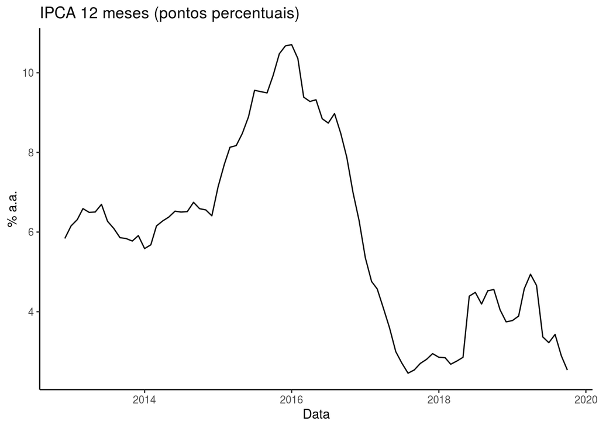

```r
ipca_mes_ano_12m %>%
  na.omit() %>%
  ggplot(aes(x = data, y = var_12m)) +
  geom_line() +
  labs(title = "IPCA 12 meses (pontos percentuais)",
       x = "Data",
       y = "% a.a.") +
  scale_color_viridis_c() +
  theme_classic()
```

### Incluindo as metas de inflação

Vamos ler o arquivo com as metas de inflação.

```r
metas <- read_csv2("../Data/meta_inflacao.csv")
```

```
## Using ',' as decimal and '.' as grouping mark. Use read_delim() for more control.
```

```r
head(metas)
```

```
## # A tibble: 6 x 4
##   X1      meta inferior superior
##   <chr>  <dbl>    <dbl>    <dbl>
## 1 jan/12   4.5      2.5      6.5
## 2 fev/12   4.5      2.5      6.5
## 3 mar/12   4.5      2.5      6.5
## 4 abr/12   4.5      2.5      6.5
## 5 mai/12   4.5      2.5      6.5
## 6 jun/12   4.5      2.5      6.5
```

```r
tail(metas)
```

```
## # A tibble: 6 x 4
##   X1      meta inferior superior
##   <chr>  <dbl>    <dbl>    <dbl>
## 1 mai/19  4.25     2.75     5.75
## 2 jun/19  4.25     2.75     5.75
## 3 jul/19  4.25     2.75     5.75
## 4 ago/19  4.25     2.75     5.75
## 5 set/19  4.25     2.75     5.75
## 6 out/19  4.25     2.75     5.75
```

```r
summary(metas)
```

```
##       X1                 meta          inferior        superior
##  Length:94          Min.   :4.250   Min.   :2.500   Min.   :5.750
##  Class :character   1st Qu.:4.500   1st Qu.:2.500   1st Qu.:6.000
##  Mode  :character   Median :4.500   Median :2.500   Median :6.500
##                     Mean   :4.473   Mean   :2.654   Mean   :6.293
##                     3rd Qu.:4.500   3rd Qu.:2.938   3rd Qu.:6.500
##                     Max.   :4.500   Max.   :3.000   Max.   :6.500
```

As datas foram lidas como caracter. Vamos fazer o mesmo procedimento de antes e incluir uma coluna chamada `data` no DataFrame metas.

```r
metas$data <- seq(as.Date("2012-01-01"), by = "month", length.out = 94)
metas$X1 <- NULL # Apaga a coluna
```

Agora podemos fazer um `inner_join` (merge) entre os DataFrames ipca_mes_ano_12m e metas.

```r
ipca_mes_ano_12m <- ipca_mes_ano_12m %>%
  inner_join(metas, by = "data")
```

E para plotar todas as séries, ipca_12m, meta e limites inferior e superior no mesmo gráfico vamos transformar o DataFrame para formato “longo”.

```r
ipca_metas <- ipca_mes_ano_12m %>%
  na.omit() %>%
  select(data, var_12m, meta, inferior, superior) %>%
  pivot_longer(-data)

head(ipca_metas)
```

```
## # A tibble: 6 x 3
##   data       name     value
##   <date>     <chr>    <dbl>
## 1 2012-12-01 var_12m   5.84
## 2 2012-12-01 meta      4.5
## 3 2012-12-01 inferior  2.5
## 4 2012-12-01 superior  6.5
## 5 2013-01-01 var_12m   6.15
## 6 2013-01-01 meta      4.5
```

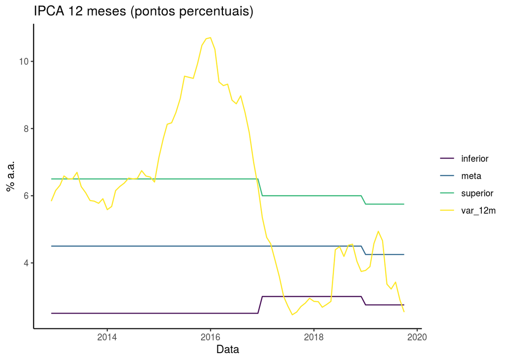

```r
ipca_metas %>%
  ggplot(aes(x = data, y = value, color = name)) +
  geom_line() +
  labs(title = "IPCA 12 meses (pontos percentuais)",
       x = "Data",
       y = "% a.a.") +
  guides(color = guide_legend(title = "")) +
  scale_color_viridis_d() +
  theme_classic()
```